# NUS DSESC DATABUSTERS TEAM 29

2025-02-12

```r
library(readr)
library(quantmod)
library(dplyr)
```

```r
library(ggplot2)
library(gridExtra)
library(corrplot)
library(tseries)
library(xts)
library(forecast)
library(zoo)
library(lmtest)
library(vars)
library(dynlm)
```

# Installing libraries & loading data

```r
quarterly = read.csv('2025-01.csv')
quarterly <- quarterly[-c(1,2),] # get rid of first 2 redundant rows
```

# Data Preprocessing

```r
# Change sasdate to date and datetime format
quarterly <- quarterly %>%
  mutate(sasdate = as.Date(sasdate, format = "%m/%d/%Y"))
# Calculate annual GDP growth rate manually
quarterly$gdp_growth <- 400 * log(quarterly$GDPC1 / lag(quarterly$GDPC1))
GDP <- xts(quarterly$GDPC1, quarterly$sasdate)
GDPGrowth <- xts(400 * log(GDP/lag(GDP)))


# Calculate logarithms, annual growth rates and 1st lag of growth rates
quants <- function(series) {
  data.frame(
    Level = series,
    Logarithm = log(series),
    AnnualGrowthRate = 400 * log(series / lag(series)),
    FirstLagAnnualGrowthRate = lag(400 * log(series / lag(series)))
  )
}
quarterly$t_spread <- quarterly$GS10 - quarterly$FEDFUND
quarterly$corpyield_spread <- quarterly$BAA - quarterly$AAA
```

The term spread (difference between GS10 and FEDFUND) reflects investor expectations about future economic conditions and monetary policy. It is often used as a leading economic indicator.

1️⃣ Normal Yield Curve (Positive Term Spread, GS10 > FEDFUND) → Economic Expansion - Long-term interest rates (GS10) are higher than short-term rates (FEDFUND). - This suggests that investors expect future economic growth and potential inflation. - Banks can borrow at lower short-term rates and lend at higher long-term rates, encouraging lending and investment. - Typically seen in periods of economic growth and stability.

2️⃣ Inverted Yield Curve (Negative Term Spread, GS10 < FEDFUND) → Possible Recession - Long-term interest rates (GS10) are lower than short-term rates (FEDFUND). - Investors expect future economic slowdown or recession, so they shift investments to long-term bonds, driving their yields down. - A negative spread discourages bank lending, which slows down economic activity. - Historically, yield curve inversions have preceded recessions in the U.S. (e.g., before 2001, 2008, and 2020 recessions).

```r
UNRATE_xts <- xts(quarterly$UNRATE, order.by = quarterly$sasdate)
CLAIMSx_xts <- xts(quarterly$CLAIMSx, order.by = quarterly$sasdate)
PERMIT_xts <- xts(quarterly$PERMIT, order.by = quarterly$sasdate)
ACOGNOx_xts <- xts(quarterly$ACOGNOx, order.by = quarterly$sasdate)
corpyield_xts <- xts(quarterly$corpyield_spread, order.by = quarterly$sasdate)
t_spread_xts <- xts(quarterly$t_spread, order.by = quarterly$sasdate)
UMCSENTx_xts <- xts(quarterly$UMCSENTx, order.by = quarterly$sasdate)
SP500_xts<- xts(quarterly$`S.P.500`, order.by = quarterly$sasdate)
OPHMFG_xts <- xts(quarterly$OPHMFG, order.by = quarterly$sasdate)
OPHNFB_xts <- xts(quarterly$OPHNFB, order.by = quarterly$sasdate)
OPHPBS_xts <- xts(quarterly$OPHPBS, order.by = quarterly$sasdate)
```

```r
adf.test(GDPGrowth["1960::2024"])
```

```
##
##  Augmented Dickey-Fuller Test
##
## data:  GDPGrowth["1960::2024"]
## Dickey-Fuller = -6.3814, Lag order = 6, p-value = 0.01
## alternative hypothesis: stationary
```

```r
adf.test(t_spread_xts["1960::2024"])
```

```
##
##  Augmented Dickey-Fuller Test
##
## data:  t_spread_xts["1960::2024"]
## Dickey-Fuller = -5.2766, Lag order = 6, p-value = 0.01
## alternative hypothesis: stationary
```

```r
adf.test(corpyield_xts["1960::2024"])
```

```
##
##  Augmented Dickey-Fuller Test
##
## data:  corpyield_xts["1960::2024"]
## Dickey-Fuller = -3.6877, Lag order = 6, p-value = 0.02519
## alternative hypothesis: stationary
```

```r
adf.test(CLAIMSx_xts["1967::2024"])
```

```
##
##  Augmented Dickey-Fuller Test
##
## data:  CLAIMSx_xts["1967::2024"]
## Dickey-Fuller = -5.2745, Lag order = 6, p-value = 0.01
## alternative hypothesis: stationary
```

```r
adf.test(PERMIT_xts["1967::2024"])
```

```
##
##  Augmented Dickey-Fuller Test
##
## data:  PERMIT_xts["1967::2024"]
## Dickey-Fuller = -4.0023, Lag order = 6, p-value = 0.01
## alternative hypothesis: stationary
```

```r
adf.test(ACOGNOx_xts["1992::2024"]) #non-stationary
```

```
##
##  Augmented Dickey-Fuller Test
##
## data:  ACOGNOx_xts["1992::2024"]
## Dickey-Fuller = -2.7639, Lag order = 5, p-value = 0.2588
## alternative hypothesis: stationary
```

```r
ACOGNOx_diff <- diff(ACOGNOx_xts)
adf.test(ACOGNOx_diff["1992-06::2024"])
```

```
##
##  Augmented Dickey-Fuller Test
##
## data:  ACOGNOx_diff["1992-06::2024"]
## Dickey-Fuller = -4.9529, Lag order = 5, p-value = 0.01
## alternative hypothesis: stationary
```

```r
adf.test(UMCSENTx_xts["1967::2024"]) #non-stationary
```

```
##
##  Augmented Dickey-Fuller Test
##
## data:  UMCSENTx_xts["1967::2024"]
## Dickey-Fuller = -3.1164, Lag order = 6, p-value = 0.1068
## alternative hypothesis: stationary
```

```r
UMCSENTx_diff <- diff(UMCSENTx_xts)
adf.test(UMCSENTx_diff["1967::2024"])
```

```
##
##  Augmented Dickey-Fuller Test
##
## data:  UMCSENTx_diff["1967::2024"]
## Dickey-Fuller = -6.0894, Lag order = 6, p-value = 0.01
## alternative hypothesis: stationary
```

```r
adf.test(SP500_xts["1967::2024"])#non-stationary
```

```
##
##  Augmented Dickey-Fuller Test
##
## data:  SP500_xts["1967::2024"]
## Dickey-Fuller = 2.7016, Lag order = 6, p-value = 0.99
## alternative hypothesis: stationary
```

```r
SP500_diff <- diff(SP500_xts)
adf.test(SP500_diff["1967::2024"])
```

```
##
##  Augmented Dickey-Fuller Test
##
## data:  SP500_diff["1967::2024"]
## Dickey-Fuller = -6.4741, Lag order = 6, p-value = 0.01
## alternative hypothesis: stationary
```

```r
adf.test(OPHMFG_xts["1987::2024-09"])
```

```
##
##  Augmented Dickey-Fuller Test
##
## data:  OPHMFG_xts["1987::2024-09"]
## Dickey-Fuller = 0.46578, Lag order = 5, p-value = 0.99
## alternative hypothesis: stationary
```

```r
adf.test(OPHNFB_xts["1967::2024-09"])
```

```
##
##  Augmented Dickey-Fuller Test
##
## data:  OPHNFB_xts["1967::2024-09"]
## Dickey-Fuller = -1.5812, Lag order = 6, p-value = 0.7519
## alternative hypothesis: stationary
```

```r
adf.test(OPHPBS_xts["1967::2024-09"])
```

```
##
##  Augmented Dickey-Fuller Test
##
## data:  OPHPBS_xts["1967::2024-09"]
## Dickey-Fuller = -1.6426, Lag order = 6, p-value = 0.7261
## alternative hypothesis: stationary
```

```r
OPHMFG_diff <- diff(OPHMFG_xts)
OPHNFB_diff <- diff(OPHNFB_xts)
OPHPBS_diff <- diff(OPHPBS_xts)
adf.test(OPHMFG_diff["1987-06::2024-09"])
```

```
##
##  Augmented Dickey-Fuller Test
##
## data:  OPHMFG_diff["1987-06::2024-09"]
## Dickey-Fuller = -5.0276, Lag order = 5, p-value = 0.01
## alternative hypothesis: stationary
```

```r
adf.test(OPHNFB_diff["1967::2024-09"])
```

```
##
##  Augmented Dickey-Fuller Test
##
## data:  OPHNFB_diff["1967::2024-09"]
## Dickey-Fuller = -6.4122, Lag order = 6, p-value = 0.01
## alternative hypothesis: stationary
```

```r
adf.test(OPHPBS_diff["1967::2024-09"])
```

```
##
##  Augmented Dickey-Fuller Test
##
## data:  OPHPBS_diff["1967::2024-09"]
## Dickey-Fuller = -6.3738, Lag order = 6, p-value = 0.01
## alternative hypothesis: stationary
```

```r
#now all stationary
quarterly$ACOGNOx <- c(NA, diff(quarterly$ACOGNOx))
quarterly$UMCSENTx <- c(NA, diff(quarterly$UMCSENTx))
quarterly$S.P.500 <- c(NA, diff(quarterly$S.P.500))
quarterly$OPHMFG <- c(NA, diff(quarterly$OPHMFG))
quarterly$OPHNFB<- c(NA, diff(quarterly$OPHNFB))
quarterly$OPHPBS<- c(NA, diff(quarterly$OPHPBS))
```

p-value = 0.01<0.05, we reject the null hypothesis at the 5% significance level. Hence, we have sufficient evidence to accept the alternative hypothesis and conclude that GDP growth is stationary.

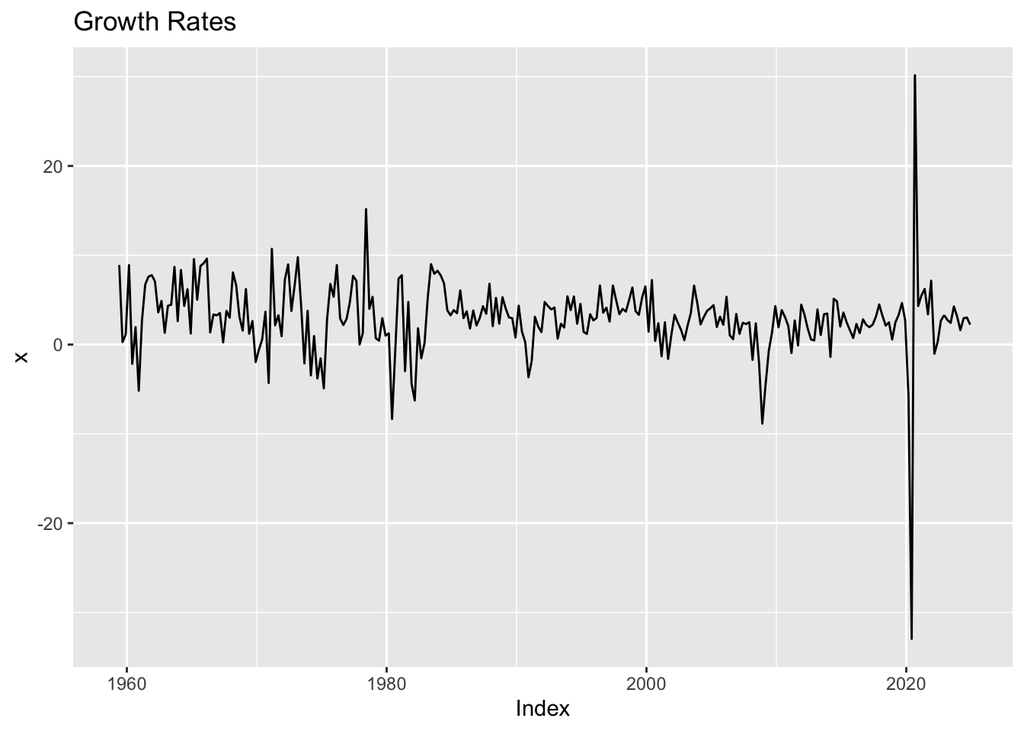

```r
#Preliminary analysis of GDP growth rate
autoplot(GDPGrowth) + ggtitle("Growth Rates")
```

# Training and forecasting with Simple ARIMA model

```r
# Split the GDPGrowth data into training and testing sets
train <- GDPGrowth["1992/2011"]
test  <- GDPGrowth["2012/2024"]

# Convert the xts objects to time series objects for modeling
train_ts <- ts(as.numeric(train), start = c(1992, 1), frequency = 4)
test_ts  <- ts(as.numeric(test),  start = c(2012, 1), frequency = 4)


# Fit an ARIMA model on the training set
fit_arima_train <- auto.arima(train_ts)
summary(fit_arima_train)
```

```
## Series: train_ts
## ARIMA(2,1,1)
##
## Coefficients:
##          ar1     ar2      ma1
##       0.2926  0.2383  -0.9570
## s.e.  0.1202  0.1177   0.0451
##
## sigma^2 = 5.191:  log likelihood = -176.31
## AIC=360.62   AICc=361.16   BIC=370.09
##
## Training set error measures:
##                      ME     RMSE      MAE        MPE    MAPE      MASE
## Training set -0.2660136 2.220743 1.627051 -0.5227327 109.052 0.6823015
##                      ACF1
## Training set 0.0003176153
```

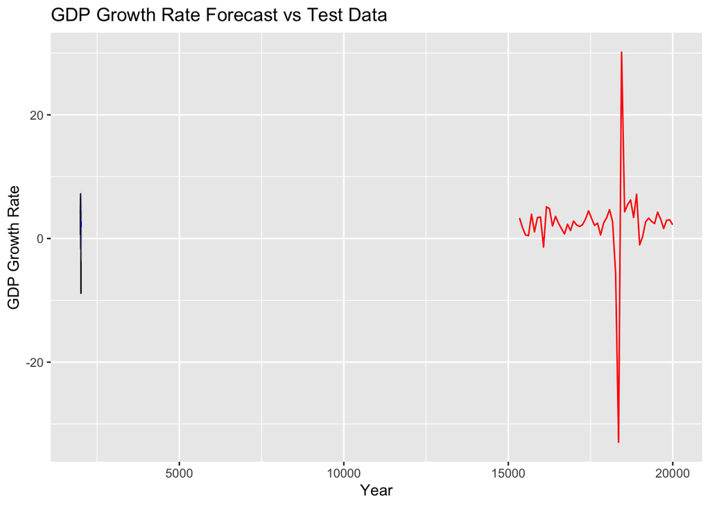

```r
# Forecast over the horizon equal to the length of the test set
forecast_horizon <- length(test_ts)
fcst_train <- forecast(fit_arima_train, h = forecast_horizon)

# Plot the forecast along with the actual test data
library(zoo)  # for as.yearqtr()

# Convert test_ts to a data frame with a Date column representing quarters
test_df <- data.frame(
  Date = as.Date(as.yearqtr(time(test_ts))),
  Test = as.numeric(test_ts)
)

# Now, plot the forecast and add the test data as a red line
autoplot(fcst_train) +
  geom_line(data = test_df, aes(x = Date, y = Test), color = "red") +
  ggtitle("GDP Growth Rate Forecast vs Test Data") +
  xlab("Year") + ylab("GDP Growth Rate")
```

```r
rmsfe <- sqrt(mean((as.numeric(fcst_train$mean) - as.numeric(test_ts))^2))
rmsfe
```

```
## [1] 6.555447
```

```r
cat("Simple model RMFSE: ", rmsfe, "\n")
```

```
## Simple model RMFSE:  6.555447
```

```r
fit_arima = auto.arima(GDPGrowth)
fit_arima
```

```
## Series: GDPGrowth
## ARIMA(3,1,2)
##
## Coefficients:
##           ar1     ar2     ar3      ma1      ma2
##       -0.9387  0.1012  0.0752  -0.0293  -0.9409
## s.e.   0.1190  0.0869  0.0649   0.1016   0.1002
##
## sigma^2 = 18.31:  log likelihood = -751.79
## AIC=1515.58   AICc=1515.91   BIC=1536.99
```

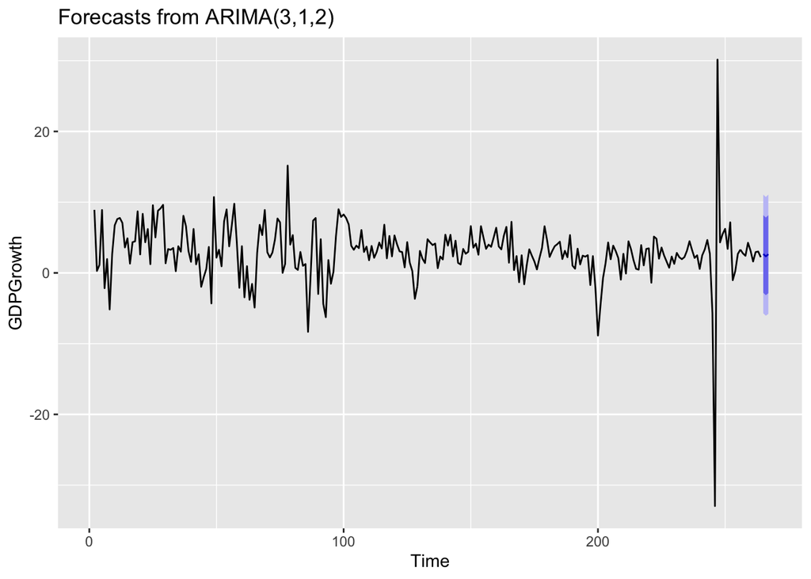

```r
fcst <- forecast(fit_arima, h=3)
autoplot(fcst)
```

```r
print(fcst)
```

```
##     Point Forecast     Lo 80    Hi 80     Lo 95    Hi 95
## 265       2.676338 -2.807835 8.160511 -5.710981 11.06366
## 266       2.341334 -3.145648 7.828316 -6.050281 10.73295
## 267       2.641102 -2.873726 8.155929 -5.793099 11.07530
```

# Training ARIMAX model with more predictors

```r
train <- GDPGrowth["1960/2011"]
test <- GDPGrowth["2012/2024"]
train_ts <- ts(as.numeric(train), start = c(1960, 1), frequency = 4)
test_ts  <- ts(as.numeric(test), start = c(2012, 1), frequency = 4)
```

```r
# ---------------------------
# 1. Prepare Exogenous Variables
# ---------------------------
exog_vars <- c("OPHNFB", "CLAIMSx", "PERMIT",
               "ACOGNOx", "corpyield_spread", "t_spread", "UMCSENTx", "S.P.500")
# Create an xts object for exogenous variables using the date column
exog_xts <- xts(quarterly[, exog_vars], order.by = quarterly$sasdate)

# ---------------------------
# 2. Define Training and Testing Periods for GDPGrowth
# ---------------------------
# For this example, we assume that GDPGrowth data spans from 1992 Q1 to 2024 Q4.
# We choose the training period as 1992-2011 and the test period as 2012-2024.
train <- GDPGrowth["1992-01-01/2011-12-31"]
test  <- GDPGrowth["2012-01-01/2024-12-31"]

# Convert the xts subsets into ts objects.
# IMPORTANT: Set the start dates to reflect the actual periods.
train_ts <- ts(as.numeric(train), start = c(1992, 1), frequency = 4)
test_ts  <- ts(as.numeric(test), start = c(2012, 1), frequency = 4)  # was incorrectly set to 2017

cat("Training period: ", start(train_ts), "to", end(train_ts), "\n")
```

```
## Training period:  1992 1 to 2011 4
```

```r
cat("Test period: ", start(test_ts), "to", end(test_ts), "\n")
```

```
## Test period:  2012 1 to 2024 4
```

```r
# ---------------------------
# 3. Align Exogenous Variables with the Training and Testing Periods
# ---------------------------
# Subset exogenous variables to the same date ranges
exog_train <- exog_xts["1992-01-01/2011-12-31"]
exog_test  <- exog_xts["2012-01-01/2024-12-31"]

# Convert these subsets to ts objects with matching start dates
exog_train_ts <- ts(as.matrix(exog_train), start = c(1992, 1), frequency = 4)
exog_test_ts  <- ts(as.matrix(exog_test), start = c(2012, 1), frequency = 4)

# ---------------------------
# 4. Fit the ARIMAX Model Using the Training Data
# ---------------------------
# Combine GDPGrowth (target) with the exogenous regressors and remove any NA rows
combined_train <- na.omit(cbind(train_ts, exog_train_ts))
train_ts_clean <- combined_train[, 1]
exog_train_ts_clean <- combined_train[, -1]

# Fit an ARIMAX model (ARIMA with exogenous variables)
fit_arimax_train <- auto.arima(train_ts_clean,
                               xreg = exog_train_ts_clean,
                               stepwise = FALSE,
                               approximation = FALSE)
print(fit_arimax_train)
```

```
## Series: train_ts_clean
## Regression with ARIMA(0,0,0) errors
##
## Coefficients:
##       intercept  exog_train_ts.OPHNFB  exog_train_ts.CLAIMSx
##         11.2894                2.6149                  0e+00
## s.e.     1.6258                0.2916                  1e-04
##       exog_train_ts.PERMIT  exog_train_ts.ACOGNOx
##                     -6e-04                  0e+00
## s.e.                 4e-04                  1e-04
##       exog_train_ts.corpyield_spread  exog_train_ts.t_spread
##                              -2.0985                  0.5292
## s.e.                          0.5700                  0.1345
##       exog_train_ts.UMCSENTx  exog_train_ts.S.P.500
##                       0.0373                 0.0044
## s.e.                  0.0343                 0.0030
##
## sigma^2 = 1.528:  log likelihood = -124.07
## AIC=268.15   AICc=271.38   BIC=291.84
```

```r
# ---------------------------
# 5. Forecast Using the ARIMAX Model
# ---------------------------
# Check that the dimensions of exog_test_ts match the length of test_ts
if(nrow(exog_test_ts) != length(test_ts)){
  stop("Mismatch between test_ts and exog_test_ts dimensions. Please check the subsetting.")
}

# Forecast over the test period using the exogenous regressors
fcst_arimax <- forecast(fit_arimax_train, xreg = exog_test_ts, h = length(test_ts))
```

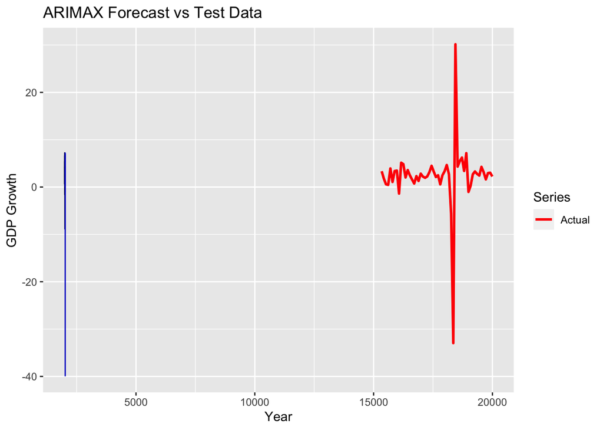

```r
# ---------------------------
# 6. Plot Forecast vs. Actual Data
# ---------------------------
library(zoo)  # for as.yearqtr conversion
test_df <- data.frame(
  Date = as.Date(as.yearqtr(time(test_ts))),
  TestData = as.numeric(test_ts)
)

autoplot(fcst_arimax, series = "Forecast") +
  geom_line(data = test_df, aes(x = Date, y = TestData, color = "Actual"), size = 1) +
  ggtitle("ARIMAX Forecast vs Test Data") +
  xlab("Year") +
  ylab("GDP Growth") +
  scale_colour_manual(name = "Series", values = c("Forecast" = "blue", "Actual" = "red"))
```

```r
# ---------------------------
# 7. Compute Forecast Accuracy (RMSFE)
# ---------------------------
forecast_values_arimax <- fcst_arimax$mean
actual_values_arimax <- test_ts
rmsfe_arimax <- sqrt(mean((actual_values_arimax - forecast_values_arimax)^2, na.rm = TRUE))
cat("ARIMAX RMSFE:", rmsfe_arimax, "\n")
```

```
## ARIMAX RMSFE: 6.32765
```

# Forecasting ARIMAx model with more predictors

```r
train <- GDPGrowth["1960/2016"]
test <- GDPGrowth["2017/2024"]
train_ts <- ts(as.numeric(train), start = c(1960, 1), frequency = 4)
test_ts  <- ts(as.numeric(test), start = c(2017, 1), frequency = 4)
```

```r
# Prepare Exogenous Variables
# ---------------------------
# (Chosen exogenous variables; adjust names as needed.)
exog_vars <- c("OPHNFB",  "CLAIMSx", "PERMIT",
               "ACOGNOx", "corpyield_spread", "t_spread", "UMCSENTx", "S.P.500")

# If any exogenous series are nonstationary, difference them here.
# (For example, if AWOTMAN were included, you would difference it.)
# In this example, we assume the chosen variables are already stationary or have been preprocessed.

# Create an xts object for the exogenous variables using sasdate as the index.
exog_xts <- xts(quarterly[, exog_vars], order.by = quarterly$sasdate)


train <- GDPGrowth["1992-01-01/2024-12-31"]

train_ts <- ts(as.numeric(train), start = c(1992, 1), frequency = 4)
cat("Training period: ", start(train_ts), "to", end(train_ts), "\n")
```

```
## Training period:  1992 1 to 2024 4
```

```r
# ---------------------------
# 4. Align Exogenous Variables with the Training and Test Periods
# ---------------------------
# Use explicit dates to subset exog_xts.
exog_train <- exog_xts["1992-01-01/2024-12-31"]

# Check dimensions to ensure they are nonempty:
cat("Dimensions of exog_train:", dim(exog_train), "\n")
```

```
## Dimensions of exog_train: 132 8
```

```r
# cat("Dimensions of exog_test:", dim(exog_test), "\n")

# Convert exog_train and exog_test to ts objects.
exog_train_ts <- ts(as.matrix(exog_train), start = c(1992, 1), frequency = 4)
#exog_test_ts <- ts(as.matrix(exog_test), start = c(2024, 4), frequency = 4)

# ---------------------------
# 5. Fit ARIMAX Model
# ---------------------------
# Combine training GDPGrowth with exogenous regressors and remove any rows with NAs.
combined_train <- na.omit(cbind(train_ts, exog_train_ts))
train_ts_clean <- combined_train[, 1]
exog_train_ts_clean <- combined_train[, -1]

# Fit the ARIMAX model using auto.arima (exhaustive search)
fit_arimax_train <- auto.arima(train_ts_clean,
                               xreg = exog_train_ts_clean,
                               stepwise = FALSE,
                               approximation = FALSE)
print(fit_arimax_train)
```

```
## Series: train_ts_clean
## Regression with ARIMA(0,0,0) errors
##
## Coefficients:
##       intercept  exog_train_ts.OPHNFB  exog_train_ts.CLAIMSx
##          2.6435                1.1268                  0e+00
## s.e.     1.5417                0.4241                  1e-04
##       exog_train_ts.PERMIT  exog_train_ts.ACOGNOx
##                      1e-03                  3e-04
## s.e.                 7e-04                  1e-04
##       exog_train_ts.corpyield_spread  exog_train_ts.t_spread
##                               0.3004                  0.1797
## s.e.                          0.8109                  0.2228
##       exog_train_ts.UMCSENTx  exog_train_ts.S.P.500
##                       0.1153                 0.0077
## s.e.                  0.0570                 0.0028
##
## sigma^2 = 8.09:  log likelihood = -315.69
## AIC=651.38   AICc=653.23   BIC=680.06
```

```r
# Plot the forecast for the next 3 quarters (Q1 2025, Q2 2025, Q3 2025)
library(forecast)

# Define the forecast period: 2025-03-01, 2025-06-01, 2025-09-01
forecast_dates <- as.Date(c("2025-03-01", "2025-06-01", "2025-09-01"))

# Create the exogenous input for the forecast period, assuming these values are constant (or based on your assumptions)
exog_future_ts <- matrix(rep(tail(exog_train_ts_clean, 1), 3), ncol = ncol(exog_train_ts_clean), byrow = TRUE)

# Forecast for the next 3 periods (March, June, September 2025)
forecasted <- forecast(fit_arimax_train, xreg = exog_future_ts, h = 3)
# Create forecast_xts using the exact forecast dates
forecast_xts <- xts(forecasted$mean, order.by = forecast_dates)

# Print the forecast results
print(forecast_xts)
```

```
##                [,1]
## 2025-03-01 3.588221
## 2025-06-01 3.588221
## 2025-09-01 3.588221
```

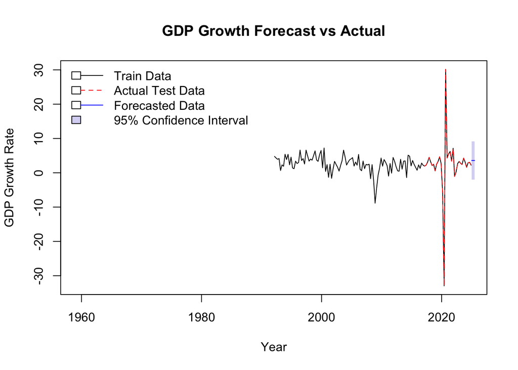

```r
# Forecast on the test set
# forecasted <- forecast(model, h = length(test))
forecast_dates <- seq(from = as.Date("2025-01-01"), by = "quarter", length.out = 3)

# Convert forecast and actual test data to xts objects
forecast_xts <- xts(forecasted$mean, order.by = forecast_dates)
lower_bound <- xts(forecasted$lower[,2], order.by = as.Date(index(forecast_dates)))
upper_bound <- xts(forecasted$upper[,2], order.by = as.Date(index(forecast_dates)))

# Plot the train, actual, and forecasted data
plot(index(train), coredata(train), type = "l", col = "black", xlab = "Year", ylab = "GDP Growth Rate",
     main = "GDP Growth Forecast vs Actual", xlim = range(index(GDPGrowth)), ylim = range(c(train, test, forecast_xts, lower_bound, upper_bound)))
lines(index(test), coredata(test), col ="red", lty = 2)  # Actual test data
lines(index(forecast_xts), coredata(forecast_xts), col = "blue")  # Forecasted data

# Add confidence intervals
polygon(c(index(forecast_xts), rev(index(forecast_xts))),
        c(coredata(lower_bound), rev(coredata(upper_bound))),
        col = rgb(0.1, 0.1, 0.8, 0.2), border = NA)

# Add a legend
legend("topleft", legend = c("Train Data", "Actual Test Data", "Forecasted Data", "95% Confidence Interval"),
       col = c("black", "red", "blue", rgb(0.1, 0.1, 0.8, 0.2)), lty = c(1, 2, 1, NA), lwd = c(1, 1, 1, NA), fill = c(NA, NA, NA, rgb(0.1, 0.1, 0.8, 0.2)), bty = "n")
```